# SLE WB PLIER cell type analyses

**J. Taroni 2018**

Part of the motivation behind using PLIER (particularly in a systemic lupus erythematosus whole blood setting) is that we can automatically extract information about cell type proportion variation. One of the datasets included in the SLE WB compendium comes from [Banchereau, et al.](https://doi.org/10.1016/j.cell.2016.03.008). The original publication contained some interesting findings about neutrophils and plasmablasts. In this notebook, we explore whether latent variables from the PLIER model trained on the SLE WB compendium associated with these cell type (gene sets) show similar trends to what was found by Banchereau, et al. By extension, this also tells us whether the cell type-specific patterns are retained following all the processing we did in [`greenelab/rheum-plier-data/sle-wb`](https://github.com/greenelab/rheum-plier-data/tree/4be547553f24fecac9e2f5c2b469a17f9df253f0/sle-wb).

## Functions and directory set up

```r
`%>%` <- dplyr::`%>%`
library(PLIER)
# custom functions
source(file.path("util", "plier_util.R"))
```

```r
# plot and result directory setup for this notebook
plot.dir <- file.path("plots", "06")
dir.create(plot.dir, recursive = TRUE, showWarnings = FALSE)
results.dir <- file.path("results", "06")
dir.create(results.dir, recursive = TRUE, showWarnings = FALSE)
```

## Load data

### PLIER model

```r
# SLE WB model trained in notebook 05
model.file <- file.path("results", "05", "SLE-WB_PLIER_model.RDS")
plier.results <- readRDS(model.file)
# summary data.frame (pathway to LV info like AUC, FDR)
sle.summary <- plier.results$summary
# LVs
b.matrix <- plier.results$B
```

### Banchereau, et al. Sample Data Relationship File

```r
# phenotype information
# read in sample data relationship file
file.65391 <- file.path("data", "sample_info", "E-GEOD-65391.sdrf.txt")
e.65391.sdrf <- readr::read_tsv(file.65391)
# use Sample instead of Source Name
colnames(e.65391.sdrf)[1] <- c("Sample")
# get rid of trailing " 1" so they match the sample names from B matrix
e.65391.sdrf$Sample <- gsub(" 1", "", e.65391.sdrf$Sample)
```

## Neutrophil signature

### LVs associated with neutrophil gene sets

```r
sle.summary %>%
  dplyr::filter(grepl("Neutrophil", pathway),
                FDR < 0.05)
```

| pathway | LV index | AUC | p-value | FDR |
| --- | --- | --- | --- | --- |
| IRIS_Neutrophil-Resting | 2 | 0.7687069 | 1.305002e-19 | 8.776135e-18 |
| SVM Neutrophils | 2 | 0.9747975 | 6.867119e-13 | 2.463007e-11 |
| IRIS_Neutrophil-Resting | 27 | 0.7372006 | 3.308839e-12 | 9.889752e-11 |
| SVM Neutrophils | 27 | 0.9661160 | 6.812259e-10 | 1.322620e-08 |
| IRIS_Neutrophil-Resting | 33 | 0.6639289 | 6.171868e-06 | 4.548583e-05 |
| IRIS_Neutrophil-Resting | 34 | 0.8525899 | 8.371128e-24 | 9.007334e-22 |
| SVM Neutrophils | 34 | 0.8565300 | 2.851473e-06 | 2.377599e-05 |
| IRIS_Neutrophil-Resting | 69 | 0.7217031 | 1.514114e-10 | 3.702697e-09 |
| IRIS_Neutrophil-Resting | 87 | 0.8567242 | 1.325077e-22 | 1.188152e-20 |
| SVM Neutrophils | 87 | 0.9539357 | 1.297526e-08 | 1.662069e-07 |

Based on these results, we select `LV2`,`LV27`, `LV34`, and `LV87` for further exploration. If these latent variables are also strongly associated with *other* pathways or cell types, that is not desirable. That could make intepretation more difficult.

```r
sle.summary %>%
  dplyr::filter(`LV index` %in% c(2, 27, 34, 87)) %>%
  dplyr::filter(FDR < 0.05) %>%
  dplyr::arrange(`LV index`, desc(AUC))
```

| pathway | LV index | AUC | p-value | FDR |
| --- | --- | --- | --- | --- |
| SVM Neutrophils | 2 | 0.9747975 | 6.867119e-13 | 2.463007e-11 |
| SVM Monocytes | 2 | 0.8568624 | 2.016055e-07 | 2.046486e-06 |
| DMAP_GRAN2 | 2 | 0.8166390 | 6.883524e-10 | 1.322620e-08 |
| IRIS_Neutrophil-Resting | 2 | 0.7687069 | 1.305002e-19 | 8.776135e-18 |
| DMAP_GRAN3 | 2 | 0.7090714 | 8.082678e-06 | 5.721686e-05 |
| SVM Neutrophils | 27 | 0.9661160 | 6.812259e-10 | 1.322620e-08 |
| IRIS_Neutrophil-Resting | 27 | 0.7372006 | 3.308839e-12 | 9.889752e-11 |
| DMAP_MONO2 | 27 | 0.7359149 | 1.765942e-05 | 1.144671e-04 |
| SVM Neutrophils | 34 | 0.8565300 | 2.851473e-06 | 2.377599e-05 |
| IRIS_Neutrophil-Resting | 34 | 0.8525899 | 8.371128e-24 | 9.007334e-22 |

[output cut: 3 more lines]

Some notes on these results:

- `LV2` looks like it captures the myeloid lineage in a broad sense, as a monocyte gene set, `SVM Monocytes`, and a neutrophil progenitor gene set, `DMAP_GRAN2` (reported to be a neutrophilic metamyelocyte signature in the [DMAP paper](https://doi.org/10.1016/j.cell.2011.01.004)).
- `LV27` and `LV34` also look like they may capture some information about monocytes because of their association with the `DMAP_MONO2` gene set.
- `LV87` looks the most “neutrophil-specific” and therefore, the most desirable for this kind of analysis.

#### U matrix

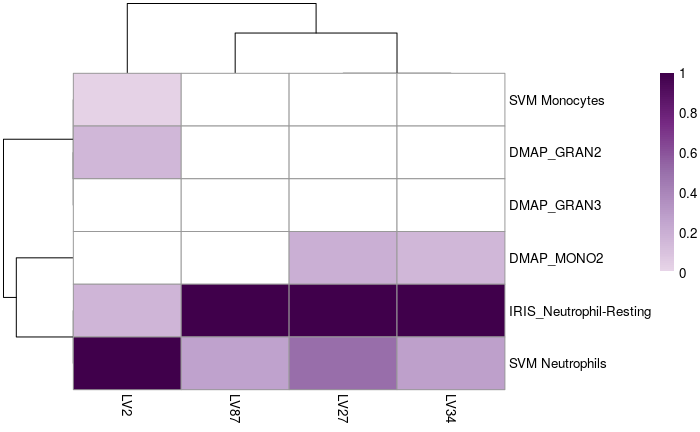

```r
PLIER::plotU(plierRes = plier.results,
             pval.cutoff = 1e-06,
             indexCol = c(2, 27, 34, 87),
             top = 10)
```

```r
png(file.path(plot.dir, "SLE_WB_neutrophil_Uplot.png"),
    res = 300, width = 7, height = 7, units = "in")
PLIER::plotU(plierRes = plier.results,
             pval.cutoff = 1e-06,
             indexCol = c(2, 27, 34, 87),
             top = 10)
dev.off()
```

### Compare to neutrophil count from Banchereau, et al.

```r
neutrophil.count.df <- e.65391.sdrf[, c("Sample",
                                        "Characteristics [neutrophil_count]")]
colnames(neutrophil.count.df)[2] <- c("Neutrophil.Count")
neutrophil.count.df <-
  neutrophil.count.df %>%
  dplyr::filter(Neutrophil.Count != "Data Not Available") %>%
  dplyr::filter(Neutrophil.Count != "Not Applicable")
```

```r
# combine with neutrophil latent variables
neutro.lv.df <- as.data.frame(cbind(colnames(b.matrix),
                                    t(b.matrix[c(2, 27, 34, 87), ])))
colnames(neutro.lv.df) <- c("Sample", "LV2", "LV27", "LV34", "LV87")
neutro.df <- dplyr::inner_join(neutro.lv.df, neutrophil.count.df,
                               by = "Sample") %>%
  dplyr::mutate(LV2 = as.numeric(as.character(LV2)),
                LV27 = as.numeric(as.character(LV27)),
                LV34 = as.numeric(as.character(LV34)),
                LV87 = as.numeric(as.character(LV87)),
                Neutrophil.Count = as.numeric(as.character(Neutrophil.Count)))
```

```
Column `Sample` joining factor and character vector, coercing into character vector
```

```r
neutro.df
```

| Sample | LV2 | LV27 | LV34 | LV87 | Neutrophil.Count |
| --- | --- | --- | --- | --- | --- |
| GSM1594269 | 1.186139e-02 | 2.667360e-01 | -0.1905490634 | 2.231298e-01 | 5.6800 |
| GSM1594270 | 6.286237e-03 | -1.166950e-01 | 0.1231715716 | -2.585397e-01 | 1.7300 |
| GSM1594271 | 1.010349e-01 | 2.390618e-01 | 0.6676743154 | 4.553055e-01 | 4.1600 |
| GSM1594273 | -2.747377e-03 | -3.200549e-01 | -0.1520023211 | 2.697605e-02 | 2.5200 |
| GSM1594274 | -9.482926e-02 | 2.263256e-01 | 0.4547308712 | 1.756054e-01 | 4.9600 |
| GSM1594275 | 8.841024e-02 | 1.747249e-02 | 0.0597894283 | -1.891333e-02 | 2.4000 |
| GSM1594276 | 1.002221e-01 | 4.394673e-01 | 0.1679870536 | 1.630192e-01 | 4.6900 |
| GSM1594277 | 9.734100e-02 | 1.144185e-01 | 0.0416107119 | 1.868851e-01 | 2.6800 |
| GSM1594278 | 1.308923e-01 | 2.759628e-02 | 0.0746125771 | 3.260544e-01 | 3.1000 |
| GSM1594279 | -1.344921e-01 | 9.884450e-02 | 0.1538043910 | -7.581119e-01 | 2.7400 |

[output cut: 843 more lines]

```r
# write to file, will use to compare to results with recount2
count.file <- file.path(results.dir,
                        "Banchereau_count_SLE_model_neutrophil_LV.tsv")
readr::write_tsv(neutro.df, path = count.file)
```

```r
# function for scatter plots, given lv (a string indicating the LV of interest)
# make a scatter plot where the LV is the x variable, neutrophil count is the
# y variable & fit a line with geom_smooth(method = "lm")
# also will annotate the plot with the supplied r-squared value (rsq arg)
# where the text is placed is automatically chosen from the x and y values
# needs to be used in this global environment
LVScatter <- function(lv, rsq) {
  y.var <- "Neutrophil.Count"

  # calculate where to put the r-squared value
  x.range <- max(neutro.df[, lv]) - min(neutro.df[, lv])
  x.coord <- min(neutro.df[, lv]) + (x.range * 0.15)
  y.range <- max(neutro.df[, y.var]) - min(neutro.df[, y.var])
  y.coord <- max(neutro.df[, y.var]) - (y.range * 0.15)

  ggplot2::ggplot(neutro.df, ggplot2::aes_string(x = lv, y = y.var)) +
    ggplot2::geom_point(alpha = 0.7) +
    ggplot2::geom_smooth(method = "lm") +
    ggplot2::theme_bw() +
    ggplot2::labs(y = "Neutrophil Count") +
    ggplot2::theme(legend.position = "none",
                   text = ggplot2::element_text(size = 15)) +
    ggplot2::annotate("text", x = x.coord, y = y.coord,
                      label = paste("r-squared =", rsq))
}
```

#### LV2

```r
summary(lm(neutro.df$Neutrophil.Count ~ neutro.df$LV2))
```

```
Call:
lm(formula = neutro.df$Neutrophil.Count ~ neutro.df$LV2)

Residuals:
    Min      1Q  Median      3Q     Max
-4.3999 -1.4245 -0.4961  0.9463 13.9831

Coefficients:
              Estimate Std. Error t value Pr(>|t|)
(Intercept)    3.81000    0.08434   45.18   <2e-16 ***
neutro.df$LV2  8.43183    0.77393   10.89   <2e-16 ***
---
Signif. codes:  0 ‘***’ 0.001 ‘**’ 0.01 ‘*’ 0.05 ‘.’ 0.1 ‘ ’ 1

Residual standard error: 2.246 on 851 degrees of freedom
Multiple R-squared:  0.1224,    Adjusted R-squared:  0.1214
F-statistic: 118.7 on 1 and 851 DF,  p-value: < 2.2e-16
```

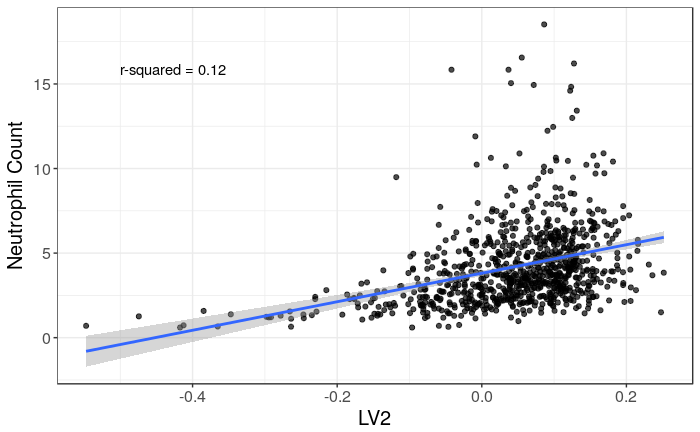

```r
LVScatter(lv = "LV2", rsq = 0.12)
```

#### LV27

```r
summary(lm(neutro.df$Neutrophil.Count ~ neutro.df$LV27))
```

```
Call:
lm(formula = neutro.df$Neutrophil.Count ~ neutro.df$LV27)

Residuals:
    Min      1Q  Median      3Q     Max
-5.0670 -1.0934 -0.1809  0.7934 12.2135

Coefficients:
               Estimate Std. Error t value Pr(>|t|)
(Intercept)     3.99216    0.06501   61.41   <2e-16 ***
neutro.df$LV27  4.66659    0.20285   23.00   <2e-16 ***
---
Signif. codes:  0 ‘***’ 0.001 ‘**’ 0.01 ‘*’ 0.05 ‘.’ 0.1 ‘ ’ 1

Residual standard error: 1.882 on 851 degrees of freedom
Multiple R-squared:  0.3834,    Adjusted R-squared:  0.3827
F-statistic: 529.2 on 1 and 851 DF,  p-value: < 2.2e-16
```

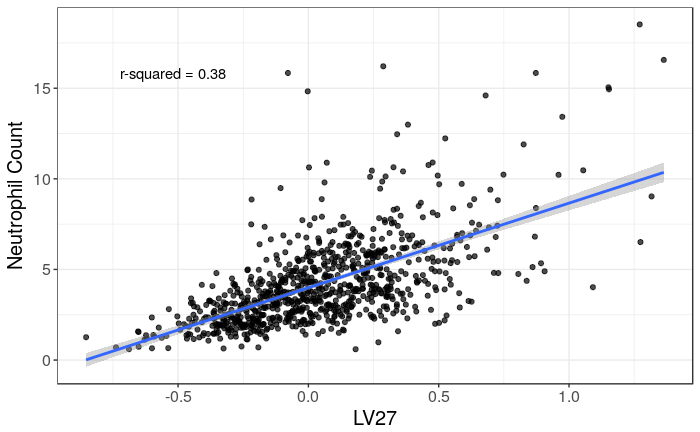

```r
LVScatter(lv = "LV27", rsq = 0.38)
```

#### LV34

```r
summary(lm(neutro.df$Neutrophil.Count ~ neutro.df$LV34))
```

```
Call:
lm(formula = neutro.df$Neutrophil.Count ~ neutro.df$LV34)

Residuals:
    Min      1Q  Median      3Q     Max
-4.9315 -1.2393 -0.2902  0.8375 11.4418

Coefficients:
               Estimate Std. Error t value Pr(>|t|)
(Intercept)     4.03189    0.06972   57.83   <2e-16 ***
neutro.df$LV34  4.11942    0.22162   18.59   <2e-16 ***
---
Signif. codes:  0 ‘***’ 0.001 ‘**’ 0.01 ‘*’ 0.05 ‘.’ 0.1 ‘ ’ 1

Residual standard error: 2.022 on 851 degrees of freedom
Multiple R-squared:  0.2888,    Adjusted R-squared:  0.2879
F-statistic: 345.5 on 1 and 851 DF,  p-value: < 2.2e-16
```

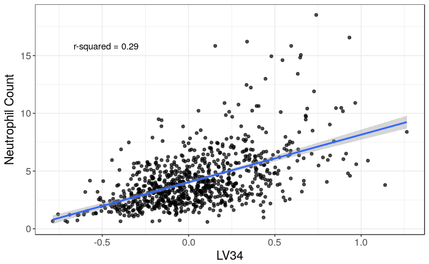

```r
LVScatter(lv = "LV34", rsq = 0.29)
```

#### LV87

```r
summary(lm(neutro.df$Neutrophil.Count ~ neutro.df$LV87))
```

```
Call:
lm(formula = neutro.df$Neutrophil.Count ~ neutro.df$LV87)

Residuals:
    Min      1Q  Median      3Q     Max
-3.9316 -1.2844 -0.3642  0.7306 12.5832

Coefficients:
               Estimate Std. Error t value Pr(>|t|)
(Intercept)     4.09067    0.06936   58.98   <2e-16 ***
neutro.df$LV87  3.37195    0.18090   18.64   <2e-16 ***
---
Signif. codes:  0 ‘***’ 0.001 ‘**’ 0.01 ‘*’ 0.05 ‘.’ 0.1 ‘ ’ 1

Residual standard error: 2.02 on 851 degrees of freedom
Multiple R-squared:  0.2899,    Adjusted R-squared:  0.2891
F-statistic: 347.5 on 1 and 851 DF,  p-value: < 2.2e-16
```

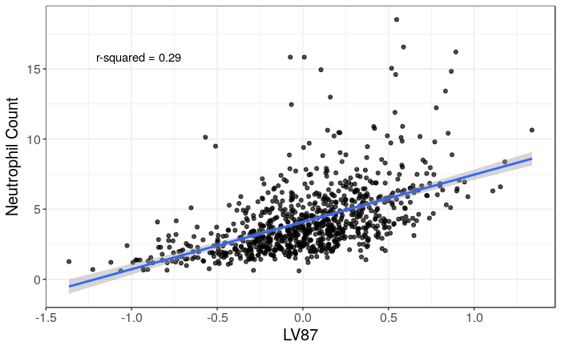

```r
LVScatter(lv = "LV87", rsq = 0.29)
```

When comparing the results to the recount2 model, we’ll pursue `LV27` because it’s the best performing and `LV87` because of its lack of overlap with monocyte signatures. So, we’ll save the plots for these two LVs.

```r
plot.file <- file.path(plot.dir, "Banchereau_neutrophil_count_LV27_scatter.png")
ggplot2::ggsave(plot.file, plot = LVScatter("LV27", rsq = 0.38))
plot.file <- file.path(plot.dir, "Banchereau_neutrophil_count_LV87_scatter.png")
ggplot2::ggsave(plot.file, plot = LVScatter("LV87", rsq = 0.29))
```

## Plasma cell signature

In Banchereau, et al., the authors demonstrated that plasmablast counts were different between patients stratified by 3 disease activity (DA) groups.

While there were no *plasmablast* gene sets given to PLIER during training, we did use *plasma cell* gene sets (isolated from PBMCs) (A plasmablast is a plasma cell precursor that is typically found in a germinal center.)

### LVs associated with plasma cell gene sets

What LVs, if any, are significantly associated with the plasma cell gene sets?

```r
sle.summary %>%
  dplyr::filter(grepl("Plasma", pathway),
                FDR < 0.05)
```

| pathway | LV index | AUC | p-value | FDR |
| --- | --- | --- | --- | --- |
| IRIS_PlasmaCell-FromBoneMarrow | 52 | 0.8361492 | 1.602642e-10 | 3.748788e-09 |
| IRIS_PlasmaCell-FromPBMC | 52 | 0.9207435 | 9.427835e-13 | 3.170110e-11 |
| SVM Plasma cells | 52 | 0.7384045 | 5.848933e-03 | 2.185734e-02 |
| SVM Plasma cells | 136 | 0.7310129 | 5.890919e-03 | 2.185734e-02 |

```r
sle.summary %>%
  dplyr::filter(`LV index` %in% c(52, 136),
                FDR < 0.05) %>%
  dplyr::arrange(desc(AUC))
```

| pathway | LV index | AUC | p-value | FDR |
| --- | --- | --- | --- | --- |
| IRIS_PlasmaCell-FromPBMC | 52 | 0.9207435 | 9.427835e-13 | 3.170110e-11 |
| IRIS_PlasmaCell-FromBoneMarrow | 52 | 0.8361492 | 1.602642e-10 | 3.748788e-09 |
| REACTOME_ASPARAGINE_N_LINKED_GLYCOSYLATION | 52 | 0.7968089 | 1.637386e-05 | 1.084749e-04 |
| REACTOME_UNFOLDED_PROTEIN_RESPONSE | 52 | 0.7713730 | 1.268342e-04 | 7.107997e-04 |
| SVM Plasma cells | 52 | 0.7384045 | 5.848933e-03 | 2.185734e-02 |
| SVM Plasma cells | 136 | 0.7310129 | 5.890919e-03 | 2.185734e-02 |
| KEGG_HEDGEHOG_SIGNALING_PATHWAY | 136 | 0.7276388 | 1.014230e-02 | 3.389167e-02 |

#### U matrix

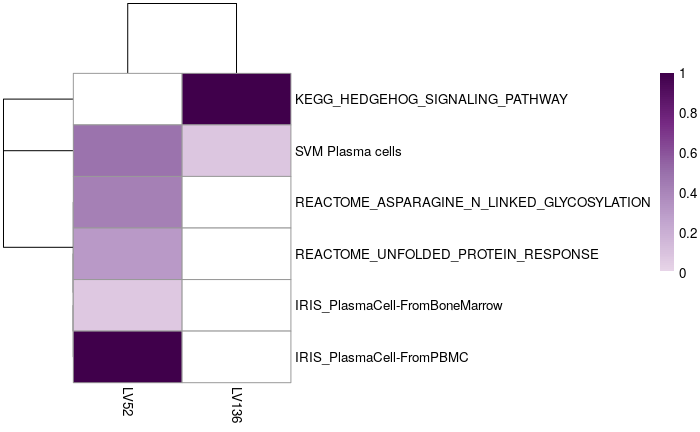

```r
PLIER::plotU(plierRes = plier.results,
             pval.cutoff = 1e-06,
             indexCol = c(52, 136),
             top = 10)
```

```r
png(file.path(plot.dir, "SLE_WB_plasma_cell_Uplot.png"),
    res = 300, width = 7, height = 7, units = "in")
PLIER::plotU(plierRes = plier.results,
             pval.cutoff = 1e-06,
             indexCol = c(52, 136),
             top = 10)
dev.off()
```

### Banchereau, et al. disease activity groups

Disease activity was defined based on SLEDAI (SLE Disease Activity Index, [Bombardier, et al. 1992.](https://www.ncbi.nlm.nih.gov/pubmed/1599520)). [Banchereau, et al.](https://doi.org/10.1016/j.cell.2016.03.008) defined the disease activity groups as follows:

> Samples were categorized as DA1 (SLEDAI: 0–2), DA2 (SLEDAI: 3–7), or DA3 (SLEDAI > 7), based on SLEDAI distribution across the cohort.

```r
# get DA information from the sample-data relationship file
da.group.df <- e.65391.sdrf[, c("Sample", "Characteristics [disease_activity]")]
colnames(da.group.df)[2] <- "Disease.Activity"
da.group.df <- da.group.df %>%
              dplyr::filter(Disease.Activity != "Not Applicable")
# plasma cell LV
plasma.lv.df <- as.data.frame(cbind(colnames(b.matrix),
                                    t(b.matrix[c(52, 136), ])))
colnames(plasma.lv.df) <- c("Sample", "LV52", "LV136")
# join
plasma.df <- dplyr::inner_join(plasma.lv.df, da.group.df) %>%
  dplyr::mutate(Disease.Activity = dplyr::recode(Disease.Activity,
                                                 `1` = "DA1",
                                                 `2` = "DA2",
                                                 `3` = "DA3"),
                Disease.Activity = factor(Disease.Activity),
                LV52 = as.numeric(as.character(LV52)),
                LV136 = as.numeric(as.character(LV136)))
```

```
Column `Sample` joining factor and character vector, coercing into character vector
```

```r
head(plasma.df)
```

|  | Sample | LV52 | LV136 | Disease.Activity |
| --- | --- | --- | --- | --- |
| 1 | GSM1594268 | 0.354004559 | -0.029880425 | DA3 |
| 2 | GSM1594269 | -0.063266973 | -0.086564899 | DA1 |
| 3 | GSM1594270 | 0.498779479 | -0.176373873 | DA3 |
| 4 | GSM1594271 | -0.144102056 | 0.050043856 | DA2 |
| 5 | GSM1594272 | 0.008078649 | -0.006313806 | DA3 |
| 6 | GSM1594273 | -0.126391548 | -0.035346313 | DA2 |

```r
# write to file, will be used to compare to recount2 model
plasma.file <- file.path(results.dir,
                         "Banchereau_DA_group_SLE_model_plasma_cell_LVs.tsv")
readr::write_tsv(plasma.df, path = plasma.file)
```

#### Plotting

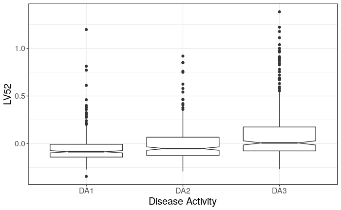

```r
plasma.df %>%
  ggplot2::ggplot(ggplot2::aes(x = Disease.Activity,
                               y = LV52)) +
  ggplot2::geom_boxplot(notch = TRUE) +
  ggplot2::theme_bw() +
  ggplot2::labs(x = "Disease Activity") +
  ggplot2::theme(text = ggplot2::element_text(size = 15))
```

```r
plot.file <- file.path(plot.dir, "Banchereau_DA_group_LV52_boxplot.png")
ggplot2::ggsave(filename = plot.file, plot = ggplot2::last_plot())
```

```r
# check for statistical significance
# (pairwise t-test is consistent with original publication as far as I can tell)
pairwise.t.test(x = plasma.df$LV52,
                g = plasma.df$Disease.Activity,
                p.adjust.method = "bonferroni")
```

```
    Pairwise comparisons using t tests with pooled SD

data:  plasma.df$LV52 and plasma.df$Disease.Activity

    DA1     DA2
DA2 0.012   -
DA3 < 2e-16 6.5e-08

P value adjustment method: bonferroni
```

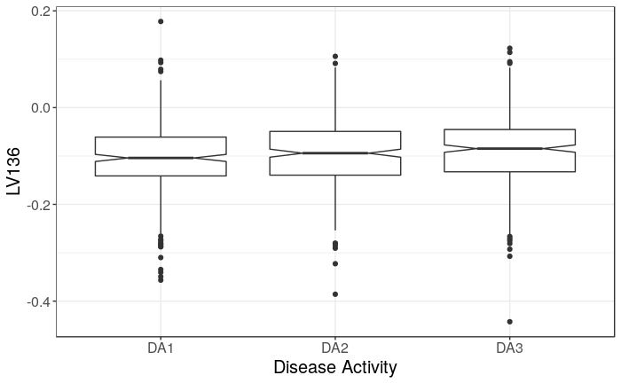

```r
plasma.df %>%
  ggplot2::ggplot(ggplot2::aes(x = Disease.Activity,
                               y = LV136)) +
  ggplot2::geom_boxplot(notch = TRUE) +
  ggplot2::theme_bw() +
  ggplot2::labs(x = "Disease Activity") +
  ggplot2::theme(text = ggplot2::element_text(size = 15))
```

```r
plot.file <- file.path(plot.dir, "Banchereau_DA_group_LV136_boxplot.png")
ggplot2::ggsave(filename = plot.file, plot = ggplot2::last_plot())
```

```r
# check for statistical significance
# (pairwise t-test is consistent with original publication as far as I can tell)
pairwise.t.test(x = plasma.df$LV136,
                g = plasma.df$Disease.Activity,
                p.adjust.method = "bonferroni")
```

```
    Pairwise comparisons using t tests with pooled SD

data:  plasma.df$LV136 and plasma.df$Disease.Activity

    DA1   DA2
DA2 0.236 -
DA3 0.018 1.000

P value adjustment method: bonferroni
```